# GET00203 - Estatística Computacional 1

Aula 10 - Coeficiente de confiança e Intervalos de confiança para a média e proporção

[Rafael Erbisti](https://sites.google.com/site/rerbisti)

### Intervalo de Confiança

Quando optamos por aproximar um parâmetro $\theta$ utilizando um valor específico do estimador $T$ (isto é, por meio de uma estimativa $T = t$), estamos determinando um **estimador pontual** para $\theta$. Nesse caso, identificamos um único valor que acreditamos aproximar o valor verdadeiro (e desconhecido) de $\theta$.

O problema com a utilização da **estimação pontual** é que, na prática, temos apenas uma amostra para avaliar o estimador. Isso implica desconsiderar a variabilidade do estimador, ou seja, o fato de que diferentes amostras poderiam gerar diferentes estimativas.

Uma solução para incorporar essa variabilidade é a **estimação intervalar**. Nesse método, além de considerar o valor estimado a partir de uma amostra específica, adicionamos uma **margem de erro** ao processo de estimação. Assim, ao invés de apontar um único valor, construímos um intervalo dentro do qual acreditamos que o parâmetro verdadeiro $\theta$ esteja contido com uma certa probabilidade (ou nível de confiança).

Se queremos estimar $\theta$, gostaríamos de obter um intervalo $[T - \varepsilon; T + \varepsilon]$ que contivesse o valor verdadeiro (e desconhecido) de $\theta$ com grande probabilidade, isto é, tal que

$$P(\theta \in [T - \varepsilon; T + \varepsilon]) = 1 - \alpha,$$

onde $1 - \alpha$ é uma probabilidade fixa (alta), chamada de **nível de confiança**, e $\alpha$ é chamado de **nível de significância**.

A probabilidade em questão é calculada com base na distribuição amostral do estimador $T$.

Nosso objetivo agora é verificar como utilizar o R para obter intervalos de confiança para parâmetros de distribuições de probabilidade.

#### Nível de Confiança

O nível de confiança é uma medida que indica a probabilidade de que um intervalo de confiança contenha o valor verdadeiro de um parâmetro populacional.

Abaixo, é ilustrado o impacto do nível de confiança em intervalos de confiança, com diferentes níveis de confiança (80%, 90% e 95%).

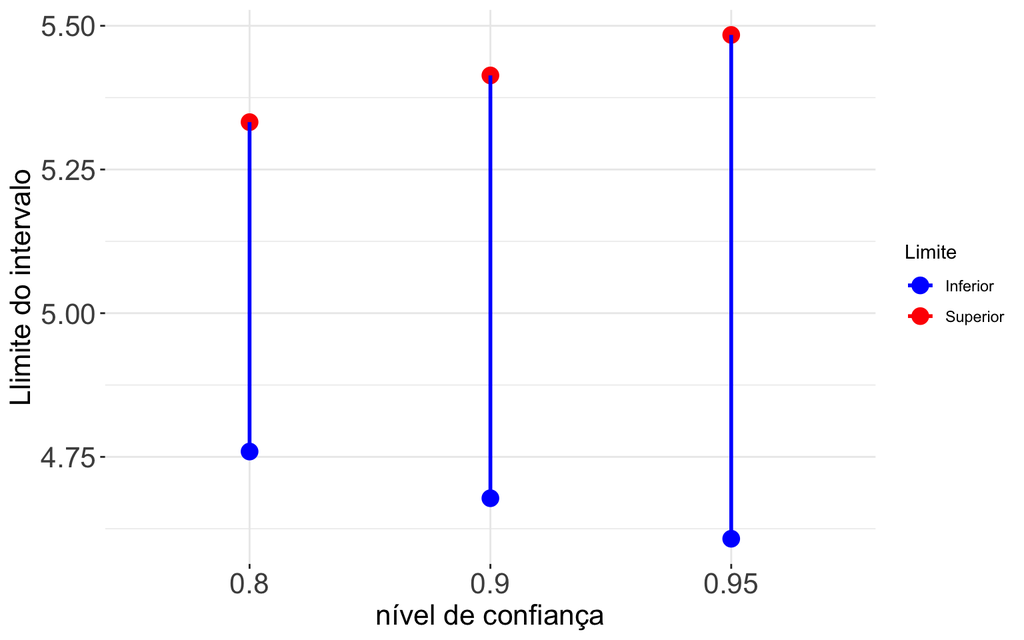

```r
# Simulação de dados
dados = rnorm(20, mean = 5, sd = 1)

# Parâmetros conhecidos
sigma = 1                      # Desvio padrão conhecido
n = length(dados)              # Tamanho da amostra
media_amostra = mean(dados)

# Função para calcular o intervalo de confiança
calcular_ic = function(conf_level, media_amostra, erro_padrao, n, sigma){
  z = qnorm(1 - (1 - conf_level) / 2)  # Quantil de z para o nível de confiança
  erro_margem = z * erro_padrao
  ic_lower = media_amostra - erro_margem
  ic_upper = media_amostra + erro_margem
  return(c(ic_lower, ic_upper))
}

# Erro padrão
erro_padrao = sigma / sqrt(n)

# Níveis de confiança
niveis_confianca = c(0.80, 0.90, 0.95)

# Calculando intervalos de confiança para cada nível
intervalos = data.frame(conf_level = rep(niveis_confianca, each = 2),
                        limite = c("Inferior", "Superior", "Inferior", "Superior", "Inferior", "Superior"),
                        valor = c(calcular_ic(0.80, media_amostra, erro_padrao, n, sigma)[1],
                                  calcular_ic(0.80, media_amostra, erro_padrao, n, sigma)[2],
                                  calcular_ic(0.90, media_amostra, erro_padrao, n, sigma)[1],
                                  calcular_ic(0.90, media_amostra, erro_padrao, n, sigma)[2],
                                  calcular_ic(0.95, media_amostra, erro_padrao, n, sigma)[1],
                                  calcular_ic(0.95, media_amostra, erro_padrao, n, sigma)[2]))

# Plotando os intervalos de confiança
ggplot(intervalos, aes(x = factor(conf_level), y = valor, color = limite)) +
  geom_point(size = 4) +
  geom_line(aes(group = conf_level), size = 1) +
  labs(x = "nível de confiança",
       y = "Llimite do intervalo",
       color = "Limite") +
  scale_color_manual(values = c("Inferior" = "blue", "Superior" = "red")) +
  theme_bw() +
  theme(axis.text.x = element_text(size = 16),
        axis.title.x = element_text(size = 16),
        axis.text.y = element_text(size = 16),
        axis.title.y = element_text(size = 16),
        panel.border = element_blank())
```

#### Interpretação do conceito de Intervalos de Confiança

Lembre-se que $\theta$ é um parâmetro (valor desconhecido), e não uma variável aleatória, então não existe probabilidade associada a $\theta$.

A probabilidade $P(\theta \in [T - \epsilon; T + \epsilon]) = 1 - \alpha$ deve ser interpretada da seguinte forma:

Se pudéssemos construir uma quantidade grande de intervalos (aleatórios) da forma $[T - \epsilon; T + \epsilon]$, todos baseados em amostras de tamanho $n$, $100(1 - \alpha)\%$ deles conteriam o valor verdadeiro do parâmetro $\theta$.

Vamos ilustrar esse conceito.

Simularemos uma distribuição normal, calcularemos intervalos de confiança para a média com diferentes amostras e verificaremos a proporção de intervalos que contêm o valor verdadeiro da média.

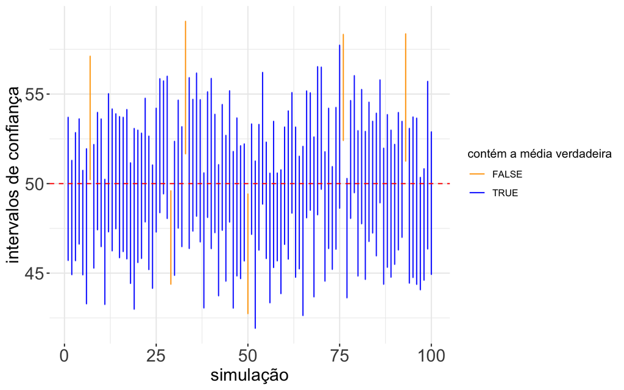

```r
# Parâmetros
true_mean = 50         # Média verdadeira
true_sd = 10           # Desvio padrão
n = 30                 # Tamanho da amostra
n_simulations = 100    # Número de simulações
conf_level = 0.95      # Nível de confiança

# Função para calcular intervalos de confiança
simula_intervalos = function(n, true_mean, true_sd, n_simulations, conf_level){
  resultados = data.frame(sim_id = 1:n_simulations,
                           lower = numeric(n_simulations),
                           upper = numeric(n_simulations),
                           contains_mean = logical(n_simulations))

  for(i in 1:n_simulations){
    sample = rnorm(n, mean = true_mean, sd = true_sd)
    sample_mean = mean(sample)
    sample_se = sd(sample) / sqrt(n)
    error_margin = qt(1 - (1 - conf_level) / 2, df = n - 1) * sample_se
    lower = sample_mean - error_margin
    upper = sample_mean + error_margin

    resultados[i, "lower"] = lower
    resultados[i, "upper"] = upper
    resultados[i, "contains_mean"] = (lower <= true_mean) & (upper >= true_mean)}

  return(resultados)
}

# Simulação
resultados = simula_intervalos(n, true_mean, true_sd, n_simulations, conf_level)

# Visualização
ggplot(resultados, aes(x = sim_id, ymin = lower, ymax = upper)) +
  geom_errorbar(aes(color = contains_mean), width = 0.2) +
  geom_hline(yintercept = true_mean, linetype = "dashed", color = "red") +
  labs(x = "simulação",
       y = "intervalos de confiança",
       color = "contém a média verdadeira") +
  scale_color_manual(values = c("TRUE" = "blue", "FALSE" = "orange")) +
  theme_bw() +
  theme(axis.text.x = element_text(size = 16),
        axis.title.x = element_text(size = 16),
        axis.text.y = element_text(size = 16),
        axis.title.y = element_text(size = 16),
        panel.border = element_blank())
```

Note que a maioria dos intervalos cobrem a linha da média verdadeira (proporção próxima ao nível de confiança, 95%). Alguns intervalos não contêm a média verdadeira, ilustrando a incerteza associada.

#### Intervalo de Confiança para Média de uma distribuição normal com variância conhecida

**Resultado**: Seja $X \sim N(\mu, \sigma^2)$, com $\sigma^2$ conhecida. Se $X_1, \dots, X_n$ é uma amostra aleatória simples (a.a.s.) de $X$, então o intervalo de confiança com nível de confiança $1 - \alpha$ para a média populacional $\mu$ é dado por

$$\left[
\bar{X} - \frac{\sigma}{\sqrt{n}} z_{1 - \frac{\alpha}{2}}, \;
\bar{X} + \frac{\sigma}{\sqrt{n}} z_{1 - \frac{\alpha}{2}}
\right],$$

onde $z_{1 - \frac{\alpha}{2}}$ é o quantil de ordem $1 - \frac{\alpha}{2}$ da distribuição normal padrão.

##### Exemplo

O tempo de reação de um novo medicamento pode ser considerado como tendo distribuição normal, e deseja-se fazer inferência sobre a média, que é desconhecida, obtendo um intervalo de confiança. Vinte pacientes foram sorteados e tiveram seus tempos de reação anotados. Supondo uma variância conhecida, igual a 1, vamos obter intervalos de confiança para a média dos tempos, com nível de confiança de 95%.

```r
# Dados
tempos = c(2.9, 3.4, 3.5, 4.1, 4.6, 4.7, 4.5, 3.8, 5.3, 4.9,
            4.8, 5.7, 5.8, 5.0, 3.4, 5.9, 6.3, 4.6, 5.5, 6.2)

# Parâmetros conhecidos
sigma2 = 1            # Variância conhecida
sigma = sqrt(sigma2)  # Desvio padrão conhecido
n = length(tempos)    # Tamanho da amostra
conf_level = 0.95     # Nível de confiança

# Estatísticas da amostra
media_amostra = mean(tempos)

# Valor crítico (z) da distribuição normal padrão
z = qnorm(1 - (1 - conf_level) / 2)

# Margem de erro
erro_margem = z * (sigma / sqrt(n))

# Intervalo de confiança
ic_lower = media_amostra - erro_margem
ic_upper = media_amostra + erro_margem

# Exibição dos resultados
cat("Intervalo de confiança para a média:",
    sprintf("[%.2f, %.2f]", ic_lower, ic_upper), "\n")
```

```
Intervalo de confiança para a média: [4.31, 5.18]
```

Ora, mas na verdade, não conhecemos a variância na prática. Neste caso, precisamos calcular a estimativa intervalar da média considerando variância desconhecida. Portanto, quando a variância é **desconhecida**, o intervalo de confiança para a média é dado por:

$$\left[
\bar{X} - \frac{s}{\sqrt{n}} t_{1 - \frac{\alpha}{2}, n-1}, \;
\bar{X} + \frac{s}{\sqrt{n}} t_{1 - \frac{\alpha}{2}, n-1}
\right],$$

onde:

- $\bar{X}$ é a média amostral
- $s$ é o desvio padrão amostral (estimativa da variância populacional)
- $n$ é o tamanho da amostra
- $t_{1 - \frac{\alpha}{2}, n-1}$ é o valor crítico da distribuição t de Student com $n-1$ graus de liberdade para o nível de confiança $1 - \alpha$.

```r
# Dados
tempos = c(2.9, 3.4, 3.5, 4.1, 4.6, 4.7, 4.5, 3.8, 5.3, 4.9,
           4.8, 5.7, 5.8, 5.0, 3.4, 5.9, 6.3, 4.6, 5.5, 6.2)

# Parâmetros conhecidos
n = length(tempos)    # Tamanho da amostra
conf_level = 0.95     # Nível de confiança

# Estatísticas da amostra
media_amostra = mean(tempos)
s = sd(tempos)  # Desvio padrão amostral

# Valor crítico t da distribuição t de Student
t_critico = qt(1 - (1 - conf_level) / 2, df = n - 1)  # t com n-1 graus de liberdade

# Margem de erro
erro_margem = t_critico * (s / sqrt(n))

# Intervalo de confiança
ic_lower = media_amostra - erro_margem
ic_upper = media_amostra + erro_margem

# Exibição dos resultados
cat("Intervalo de confiança para a média com variância desconhecida:",
    sprintf("[%.2f, %.2f]", ic_lower, ic_upper), "\n")
```

```
Intervalo de confiança para a média com variância desconhecida: [4.28, 5.21]
```

#### Intervalo de Confiança para a Média de Populações Baseado em Amostras Grandes

**TCL**: Para uma a.a.s. $(X_1, X_2, \dots, X_n)$ retiradas de uma população com média $\mu$ e variância $\sigma^2$ finita, a distribuição amostral da média $\bar{X}$ aproxima-se, para $n$ grande, de uma distribuição normal, com média $\mu$ e variância $\frac{\sigma^2}{n}$.

**Resultado**: Segue diretamente do TCL que, se $X_1, \dots, X_n$ é uma a.a.s. de $X$, com $E[X] = \mu$ e $\text{Var}(X) = \sigma^2$, então, para $n$ suficientemente grande, um intervalo de confiança aproximado com nível de confiança $1 - \alpha$ para a média populacional $\mu$ é dado por:

$$\left[
\bar{X} - \frac{\sigma}{\sqrt{n}} z_{1 - \frac{\alpha}{2}}, \;
\bar{X} + \frac{\sigma}{\sqrt{n}} z_{1 - \frac{\alpha}{2}}
\right],$$

onde:

- $\bar{X}$ é a média amostral
- $\sigma$ é o desvio padrão populacional
- $n$ é o tamanho da amostra
- $z_{1 - \frac{\alpha}{2}}$ é o quantil de ordem $1 - \frac{\alpha}{2}$ da distribuição normal padrão.

#### Intervalo de Confiança para Proporção

**Resultado**: Se $X_1, \dots, X_n$ é uma a.a.s. de $X \sim \text{Ber}(p)$, então, para $n$ suficientemente grande, temos que a distribuição amostral de $\hat{P} = \frac{X}{n}$ se aproxima de uma distribuição normal:

$$\hat{P} \sim N\left( p, \frac{p(1 - p)}{n} \right),$$

e, portanto, um intervalo de confiança aproximado com nível de confiança $1 - \alpha$ para $p$ é dado por:

$$\left[
\hat{P} - \frac{\sqrt{p(1 - p)}}{\sqrt{n}} z_{1 - \frac{\alpha}{2}}, \;
\hat{P} + \frac{\sqrt{p(1 - p)}}{\sqrt{n}} z_{1 - \frac{\alpha}{2}}
\right],$$

onde:

- $\hat{P}$ é a proporção amostral
- $p$ é a proporção populacional
- $n$ é o tamanho da amostra
- $z_{1 - \frac{\alpha}{2}}$ é o quantil de ordem $1 - \frac{\alpha}{2}$ da distribuição normal padrão.

**Duas maneiras de aproximar $p$ (desconhecido):**

1. Estimar pela proporção amostral $\hat{P}$
2. Usar o intervalo mais conservador possível, fazendo $p = \frac{1}{2}$.

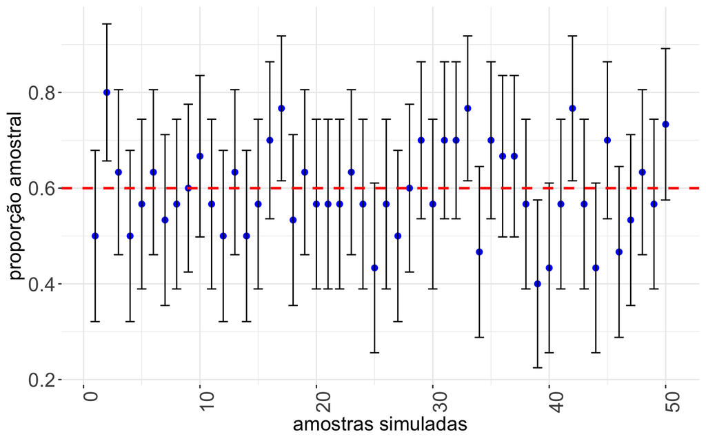

```r
# Definir parâmetros
n = 30               # Tamanho da amostra
p_pop = 0.6          # Proporção verdadeira na população
n_sim = 50           # Número de simulações
conf_level = 0.95    # Nível de confiança

# Função para calcular intervalo de confiança
calc_ic_proporcao = function(n, p_hat, conf_level) {
  z = qnorm(1 - (1 - conf_level) / 2)  # Quantil de normal para 95%
  erro_margem = z * sqrt((p_hat * (1 - p_hat)) / n)  # Margem de erro
  ic_lower = p_hat - erro_margem  # Limite inferior
  ic_upper = p_hat + erro_margem  # Limite superior
  return(c(ic_lower, ic_upper))  # Retorna o intervalo
}

# Simulação de amostras e cálculo dos intervalos de confiança
simulacoes = replicate(n_sim, {
  amostra = rbinom(n, 1, p_pop)     # Amostra binomial (sucesso ou fracasso)
  p_hat = mean(amostra)             # Proporção amostral
  ic = calc_ic_proporcao(n, p_hat, conf_level)  # Intervalo de confiança
  return(ic)
})

# Converter resultados em data.frame para visualização
ic_df = data.frame(Simulacao = 1:n_sim,
                   IC_Lower = simulacoes[1,],  # Limite inferior
                   IC_Upper = simulacoes[2,],  # Limite superior
                   P_Hat = colMeans(simulacoes))  # Proporção amostral

# Plot do intervalo de confiança para cada simulação
ggplot(ic_df, aes(x = Simulacao, y = P_Hat)) +
  geom_point(color = "blue", size = 2) +
  geom_errorbar(aes(ymin = IC_Lower, ymax = IC_Upper), width = 0.8, color = "black") +
  labs(x = "amostras simuladas",
       y = "proporção amostral") +
  geom_hline(yintercept = p_pop, linetype = "dashed", color = "red", size = 1) +
  theme_bw() +
  theme(axis.text.x = element_text(size = 16, angle = 90, hjust = 1),
        axis.title.x = element_text(size = 16),
        axis.text.y = element_text(size = 16),
        axis.title.y = element_text(size = 16),
        panel.border = element_blank())
```

> **Desafio:** A partir da teoria do Teorema do Limite Central, encontre o intervalo de confiança para a média da distribuição exponencial. Suponha uma amostra de tamanho 200 de uma população Exponencial, com média igual 1. (observação: use a semente 42)